# Graficos de analisis de componentes principales PCA´s

# Introduccion

El analisis de componentes principales o PCA por sus siglas en ingles es un metodo de reduccion de dimensionalisas que comunmente se usa para reducir la dimensionalidad de grandes sets de datos transformandos los mismos en datos simplicados que igual contengan la mayor cantidad de informacion posible del set original. Es uno de los métodos de análisis de datos multivariantes más utilizados que permite investigar conjuntos de datos multidimensionales con variables cuantitativas.

En palabras mas simples (y al nivel de estadistica en el que comprendo los PCAs) este analisis lo que hace es transformar tus datos en “distancias” que toman en cuenta todas tus variables independientes y las traduce a puntos en un plano. Los valores de las variables dependientes definen cuales puntos estaran mas cerca unos de otros en el plano y de ahi se puede determinar la relacion que existe entre tus muestras.

El resultado de los PCAs son coordenadas por lo que siempre vienen acompanados de un grafico en el cual los ejes no tienen ninguna unidad. Siempre se usan el PC 1 y el 2 para graficar ya que estos son los que tienen el mayor porcentaje de explicacion en la variacion de los datos y ese porcentaje usualmente es lo que se reporta en el grafico.

```r
library(ggfortify) # es para autoplot
```

# Calcular PCAs

```r
summary(PCAc)
```

```
Importance of components:
                          PC1    PC2     PC3     PC4     PC5     PC6
Standard deviation     5.0489 2.4236 1.47058 1.25544 1.10892 0.89462
Proportion of Variance 0.6536 0.1506 0.05545 0.04041 0.03153 0.02052
Cumulative Proportion  0.6536 0.8042 0.85968 0.90009 0.93162 0.95214
                           PC7     PC8     PC9    PC10    PC11    PC12
Standard deviation     0.68498 0.59706 0.52471 0.43547 0.41249 0.33539
Proportion of Variance 0.01203 0.00914 0.00706 0.00486 0.00436 0.00288
Cumulative Proportion  0.96417 0.97332 0.98037 0.98524 0.98960 0.99248
                         PC13    PC14    PC15   PC16    PC17    PC18
Standard deviation     0.2721 0.24780 0.22027 0.1873 0.18331 0.12157
Proportion of Variance 0.0019 0.00157 0.00124 0.0009 0.00086 0.00038
Cumulative Proportion  0.9944 0.99596 0.99720 0.9981 0.99896 0.99934
                          PC19    PC20    PC21    PC22     PC23     PC24
Standard deviation     0.10313 0.09250 0.07142 0.03709 0.006077 0.001736
Proportion of Variance 0.00027 0.00022 0.00013 0.00004 0.000000 0.000000
Cumulative Proportion  0.99961 0.99983 0.99996 1.00000 1.000000 1.000000
                            PC25
Standard deviation     3.519e-16
Proportion of Variance 0.000e+00
Cumulative Proportion  1.000e+00
```

Si se fijan al correr el resumen de este objeto dice que nos va a dar la importancia de los componentes. En este caso tenemos 25 PCAs o componentes ya que tenemos 25 muestras. Como mencione anteriormente los que usan a graficar es PC1 y 2 y para saber los porcentajes se toma la proporcion de varianza.

guardar la tabla PCAs

```r
PCAscores <- as.data.frame(PCAscoreds) %>%
  add_column(Plant_type = Exudados$Plant_type) %>%
  add_column(Treatment = Exudados$Treatment)
```

[output not shown]

# El grafico

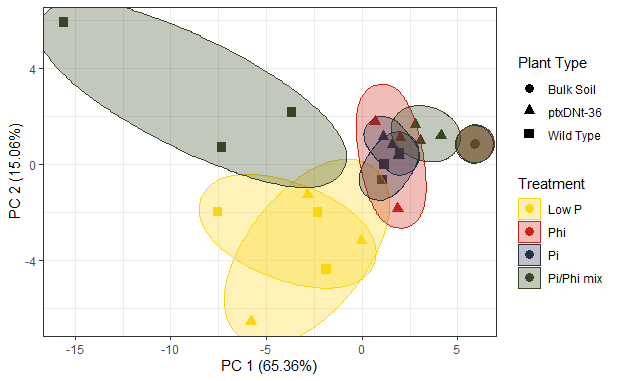

### Mini ejercicio

Cambien el nombre de las leyendas a español

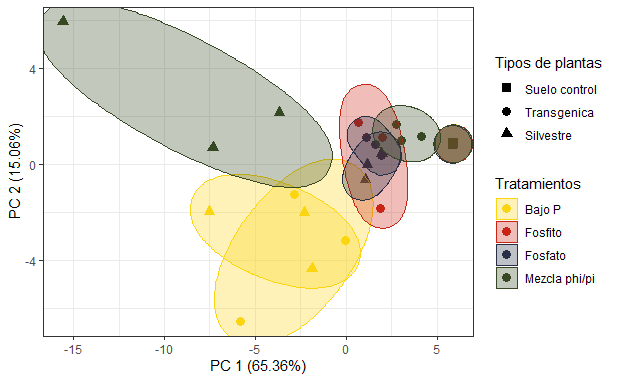

### Otras cosas que se pueden modificar en el grafico

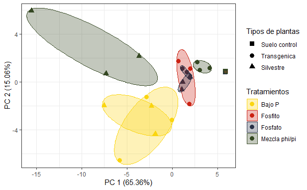

## Ejercicio

Usando los datos de grupos matabolicos crear un grafico de PCA. Usen diferentes colores y anoten correctamente los porcentajes de los PCs. Es significativo o no?

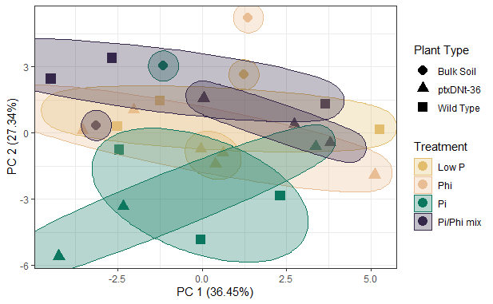

## Graficos de “Loadings”

Los graficos de “loading” muestran que tan fuerte es la influencia de cada caracteristica (variable dependiente) en el analisis de componentes principales. Las variables dependientes se grafrican como vectoreds y los mas largos son los mas importantes por definir los PCs. Vectores horizonatales influirian mas PC1 mientras que vectores verticales fluyen mas PC2.

Otra cosa interesante que nos muestran los graficos de loadings es que los angulos entre vectores nos muestran como nuestras variables dependientes se correlacionan entre si:

- Cuando dos vectores estan cerca formando un angulo muy peueño las dos variables estan correlacionadas de manera positiva
- Cuando los vectores forman un angulo de 90° entre ellos probablemnte no estan correlacionados
- Cuando estos divergen entre si en direcciones opuestas formando un angulo de 180° entan correlacionados negativamente.

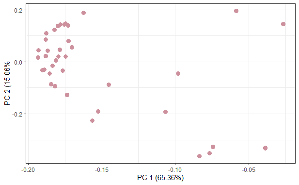

*El Grafico de loadings tiene como puentos las variables DEPENDIENTES en este caso los metabolitos mientras que el PCA tiene como puntos las muestras en este caso plantas*

El problema con este grafico son los ejes. USualmente los valores de loading van de -1 a 1 y en este caso la escala no nos deja ver bien dicha relacion. por ello hay que modiifcar la escala

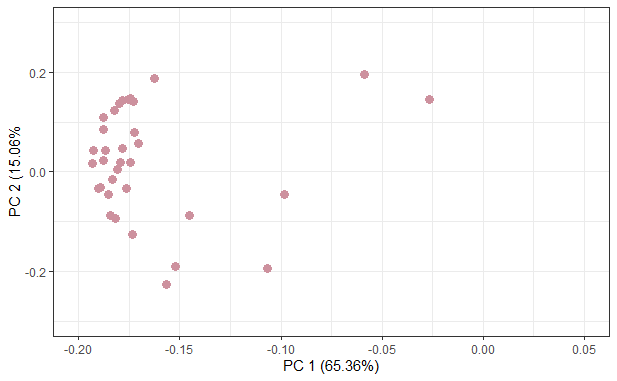

Con nuestro grafico ya centrado podemos agregar las flechas:

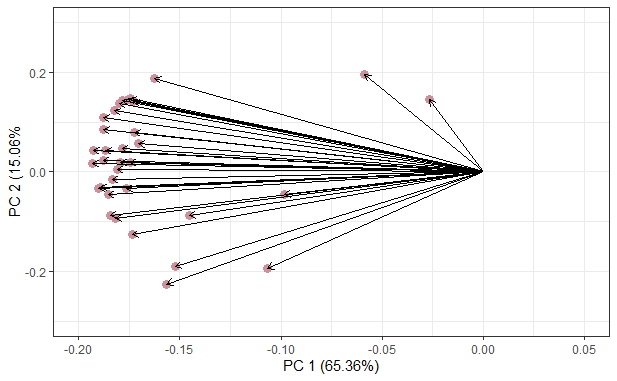

Si se fijan todos los metabolitos estan cargados a la izquierda osea a la misma direccion exceplo algunos, por lo cual se comprotan diferentes, entonces solo vamos a seleccionar los metabolios que nos importan…

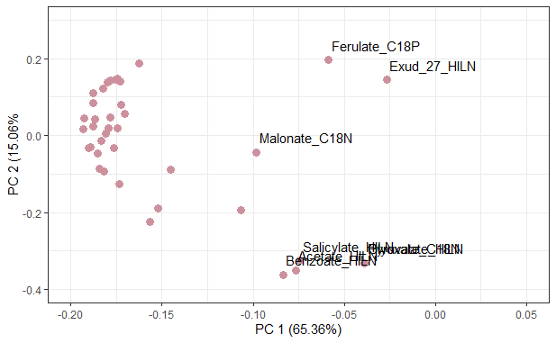

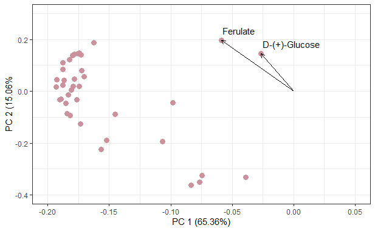

### Ejercicio

usando los datos de grupos metabolicos creen un grafico de loading y añadas todas las flechas.

[figure not shown]

# El atajo

Aunque ahorita los vimos por separado usando ambas tablas podriamos graficar el PCA que ya hicimos junto con las flechas que acabamos de graficar. Si bien se puede hacer a mano, una de las variantes de ggplot nos da un atajo para hacer de manera mas sencilla: ggfortify

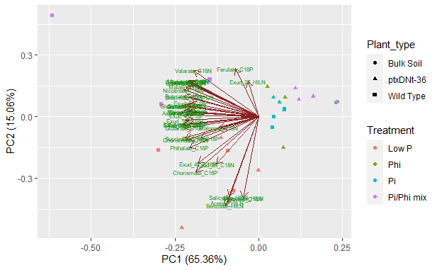

## Ejercicio final

Usando autoplot grafiquen los gupos metabolicos. Ustedes deberan decidir si quieren o no añadir etiquetas a los loadings, elipses a los datos, etc. justifiquen su respuesta al presentar el grafico.

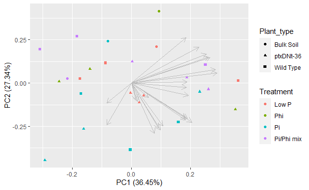